# aif360_newdataset_v0.1

## AIF360 Implementation for New Dataset

Version: 0.1  
Description: Implementation of AIF360 toolkit on dataset provided by Ambrose and YCAS  
Sources: [Medical Expenditure Tutorial (AIF360)](https://nbviewer.org/github/IBM/AIF360/blob/master/examples/tutorial_medical_expenditure.ipynb) and [AMBIATA Bias detection and mitigation](https://ambiata.com/blog/2019-12-13-bias-detection-and-mitigation/)

*Topline Summary: The model seems to perform differently depending on gender. Using the AIF360 package, we define the 'disparate index' metric to show the difference in performance, and changed the weighting of the features to decrease bias in performance.*

*Action Items:*

- Run with more 'sensitive variables'
- Run with different regression penalities (ridge, lasso/ridge hybrid)

### 1. Loading packages

```python
import sys
import matplotlib.pyplot as plt
import numpy as np
import pandas as pd
import random
import seaborn as sns


from sklearn.model_selection import train_test_split
from IPython.display import Markdown, display
from sklearn.linear_model import Lasso
from sklearn.pipeline import make_pipeline
from sklearn.preprocessing import StandardScaler


from aif360.datasets import BinaryLabelDataset
from sklearn.linear_model import LogisticRegression

# To see how fast the program runs
import datetime
```

[output not shown]

```python
# AIF360 Packages
from aif360.metrics import BinaryLabelDatasetMetric
from aif360.explainers import MetricTextExplainer
from aif360.metrics import ClassificationMetric
from aif360.algorithms.preprocessing import Reweighing
```

```
WARNING:root:No module named 'tensorflow': AdversarialDebiasing will be unavailable. To install, run:
pip install 'aif360[AdversarialDebiasing]'
WARNING:root:No module named 'tensorflow': AdversarialDebiasing will be unavailable. To install, run:
pip install 'aif360[AdversarialDebiasing]'
```

### 1.1 Loading Dataset

```python
df = pd.read_csv("../data/data_for_LASSO_new.csv")
display(df)
```

|  | age_continuous | edlos | anyrestraint | echo_ed | headct_ed | mri_ed | otherproc_ed | otherus_ed | headct_hist | ed_vital_hr_mean | ... | SmokingStatus_999 | socialadmin_1 | socialadmin_999 | substancerelateddisorders_1 | substancerelateddisorders_999 | suicideandintentionalselfi_1 | suicideandintentionalselfi_999 | superficinj_1 | superficinj_999 | trauma_dx_1 |
| --- | --- | --- | --- | --- | --- | --- | --- | --- | --- | --- | --- | --- | --- | --- | --- | --- | --- | --- | --- | --- | --- |
| 0 | 69 | 266.327898 | 0 | 0.075483 | 0.140435 | 0.038013 | 9.318478 | 0.218136 | 0.167624 | 82.586018 | ... | 0 | 0 | 0 | 0 | 0 | 0 | 0 | 0 | 0 | 1 |
| 1 | 23 | 266.327898 | 0 | 0.075483 | 0.140435 | 0.038013 | 9.318478 | 0.218136 | 0.167624 | 82.586018 | ... | 0 | 0 | 0 | 0 | 0 | 0 | 0 | 0 | 0 | 1 |
| 2 | 45 | 266.327898 | 0 | 0.075483 | 0.140435 | 0.038013 | 9.318478 | 0.218136 | 0.167624 | 82.586018 | ... | 0 | 0 | 0 | 1 | 0 | 1 | 0 | 0 | 0 | 1 |
| 3 | 53 | 354.000000 | 0 | 0.000000 | 0.000000 | 0.000000 | 4.000000 | 0.000000 | 0.167624 | 100.500000 | ... | 1 | 0 | 1 | 0 | 1 | 0 | 1 | 0 | 1 | 0 |
| 4 | 39 | 156.000000 | 0 | 0.000000 | 0.000000 | 0.000000 | 2.000000 | 0.000000 | 0.167624 | 73.500000 | ... | 0 | 0 | 0 | 1 | 0 | 0 | 0 | 1 | 0 | 1 |
| ... | ... | ... | ... | ... | ... | ... | ... | ... | ... | ... | ... | ... | ... | ... | ... | ... | ... | ... | ... | ... | ... |
| 1161968 | 73 | 266.327898 | 0 | 0.000000 | 0.000000 | 0.000000 | 6.000000 | 1.000000 | 0.167624 | 82.333330 | ... | 0 | 0 | 0 | 1 | 0 | 1 | 0 | 1 | 0 | 1 |
| 1161969 | 57 | 266.327898 | 0 | 0.000000 | 0.000000 | 0.000000 | 10.000000 | 0.000000 | 0.167624 | 73.437500 | ... | 0 | 1 | 0 | 1 | 0 | 1 | 0 | 1 | 0 | 1 |
| 1161970 | 28 | 266.327898 | 0 | 0.000000 | 0.000000 | 0.000000 | 2.000000 | 0.000000 | 0.167624 | 96.000000 | ... | 0 | 0 | 0 | 0 | 0 | 0 | 0 | 1 | 0 | 1 |
| 1161971 | 35 | 266.327898 | 0 | 0.075483 | 0.140435 | 0.038013 | 9.318478 | 0.218136 | 1.000000 | 109.000000 | ... | 0 | 1 | 0 | 1 | 0 | 0 | 0 | 1 | 0 | 1 |
| 1161972 | 49 | 266.327898 | 0 | 0.000000 | 1.000000 | 0.000000 | 5.000000 | 0.000000 | 0.000000 | 71.000000 | ... | 0 | 0 | 0 | 0 | 0 | 0 | 0 | 0 | 0 | 1 |

1161973 rows × 263 columns

### 1.2 Convert to AIF360 Dataframe

```python
# First, we need to define the privilged and unpriviled groups

privileged_groups = [{'Sex_1':1}] # 1 is male
unprivileged_groups = [{'Sex_1':0}] # 0 is female

# Convert to AIF360 dataframe
df_aif = BinaryLabelDataset(df = df, label_names = ['anyrestraint'], protected_attribute_names = ['Sex_1'])
```

### 1.3 Visualizing Bias

Say we wanted to visualize difference in outcomes (i.e., restraint) among gender.

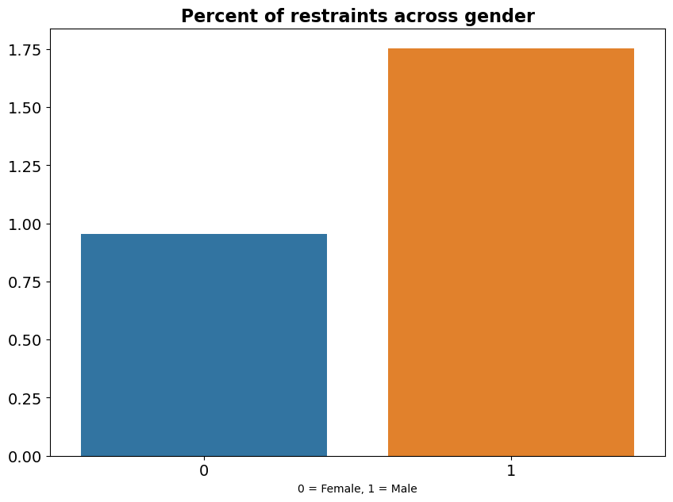

```python
agg_gender = df[['Sex_1', 'anyrestraint']].groupby('Sex_1').mean()

fig, ax1 = plt.subplots(figsize=(10, 7))
sns.barplot(x=agg_gender.index, y=agg_gender.anyrestraint*100, ax=ax1).\
set_title('Percent of restraints across gender', fontsize=16, fontweight='bold')
ax1.set(xlabel='0 = Female, 1 = Male', ylabel='')
ax1.xaxis.set_tick_params(labelsize=14)
ax1.yaxis.set_tick_params(labelsize=14)
```

### 2.1 Create splits for learning/validating/testing

Let's do a train (50%), validate (30%), test (20%) spilt.

```python
# Split into training, validation, and test datasets
dataset_original_train, dataset_original_validate, dataset_original_test = df_aif.split([0.5, 0.8], shuffle = True)
```

We can create a wrapper function to give us some information about the splits.

```python
def Describe(train=None, val=None, test=None, display_features = None):
    if train is not None:
        display(Markdown("#### Training Dataset shape"))
        print(train.features.shape)
    if val is not None:
        display(Markdown("#### Validation Dataset shape"))
        print(val.features.shape)
    display(Markdown("#### Test Dataset shape"))
    print(test.features.shape)
    display(Markdown("#### Favorable and unfavorable labels"))
    print(test.favorable_label, test.unfavorable_label)
    display(Markdown("#### Protected attribute names"))
    print(test.protected_attribute_names)
    display(Markdown("#### Privileged and unprivileged protected attribute values"))
    print(test.privileged_protected_attributes,
          test.unprivileged_protected_attributes)

    if display_features == True:
        display(Markdown("#### Dataset feature names"))
        print(test.feature_names)
```

```python
Describe(dataset_original_train, dataset_original_validate, dataset_original_test)
```

Training Dataset shape

```
(580986, 262)
```

Validation Dataset shape

```
(348592, 262)
```

Test Dataset shape

```
(232395, 262)
```

Favorable and unfavorable labels

```
1.0 0.0
```

Protected attribute names

```
['Sex_1']
```

Privileged and unprivileged protected attribute values

```
[array([1.])] [array([0.])]
```

### 2.2 Confirming bias in training dataset

Defintion of disparate index:

$$ \frac{Pr(Y = 1 | D = unprivileged)}{Pr(Y = 1 | D = privileged)} \\ $$

In other words, the disparate index can be a potential metric to tells us how good the classifier performs in among 'sensitive' groups.

```python
metric_original_train = BinaryLabelDatasetMetric(
        dataset_original_train,
        unprivileged_groups=unprivileged_groups,
        privileged_groups=privileged_groups)

def MetricTextExplainer(metric_original_train):
    print(f"Disparate impact (probability of restraint given the patient is unprivileged (female) divided by the probability of restraint given the patient is privileged (male)):", metric_original_train.disparate_impact())

explainer_original_train = MetricTextExplainer(metric_original_train)
```

```
Disparate impact (probability of restraint given the patient is unprivileged (female) divided by the probability of restraint given the patient is privileged (male)): 0.5454919466186142
```

Referring back to the figure above, this makes sense as more males are restrained as opposed to females, so we would expect the disparate impact to be <1.

### 3.1 Running Logistic Regression (LR) classifers on original data

Here we run a lasso regression by specifying `penalty = 'l1'`. We can easily run a ridge or hybrid of lasso and ridge by changing the penalty argument. `instance_weights` are the weighting for each instance and are all equal (ones) by [default](https://aif360.readthedocs.io/en/latest/modules/generated/aif360.datasets.StructuredDataset.html).

```python
%%time

dataset = dataset_original_train
model = make_pipeline(StandardScaler(),
                      LogisticRegression(solver='liblinear', penalty = 'l1', random_state=1234))
fit_params = {'logisticregression__sample_weight': dataset.instance_weights}

lr_original = model.fit(dataset.features, dataset.labels.ravel(), **fit_params)
```

```
CPU times: user 31min 21s, sys: 2.68 s, total: 31min 23s
Wall time: 31min 29s
```

### 3.2 Validating LR model on original data

We try and determine the best classification threshold (recall that logistic regression returns probabilities and we need a threshold to define whether the predicted probability indicates a positive outcome '1' or negative outcome '0') in our validation set.

```python
from collections import defaultdict

def test(dataset, model, thresh_arr):
    try:
        # sklearn classifier
        y_val_pred_prob = model.predict_proba(dataset.features)
        pos_ind = np.where(model.classes_ == dataset.favorable_label)[0][0]
    except AttributeError:
        # aif360 inprocessing algorithm
        y_val_pred_prob = model.predict(dataset).scores
        pos_ind = 0

    metric_arrs = defaultdict(list)
    for thresh in thresh_arr:
        y_val_pred = (y_val_pred_prob[:, pos_ind] > thresh).astype(np.float64)

        dataset_pred = dataset.copy()
        dataset_pred.labels = y_val_pred
        metric = ClassificationMetric(
                dataset, dataset_pred,
                unprivileged_groups=unprivileged_groups,
                privileged_groups=privileged_groups)

        metric_arrs['bal_acc'].append((metric.true_positive_rate()
                                     + metric.true_negative_rate()) / 2)
        metric_arrs['avg_odds_diff'].append(metric.average_odds_difference())
        metric_arrs['disp_imp'].append(metric.disparate_impact())
        metric_arrs['stat_par_diff'].append(metric.statistical_parity_difference())
        metric_arrs['eq_opp_diff'].append(metric.equal_opportunity_difference())
        metric_arrs['theil_ind'].append(metric.theil_index())

    return metric_arrs
```

```python
thresh_arr = np.linspace(0.01, 0.5, 50)
val_metrics = test(dataset=dataset_original_validate,
                   model=lr_original,
                   thresh_arr=thresh_arr)
lr_original_best_ind = np.argmax(val_metrics['bal_acc'])
```

```python
def plot(x, x_name, y_left, y_left_name, y_right, y_right_name):
    fig, ax1 = plt.subplots(figsize=(10,7))
    ax1.plot(x, y_left)
    ax1.set_xlabel(x_name, fontsize=16, fontweight='bold')
    ax1.set_ylabel(y_left_name, color='b', fontsize=16, fontweight='bold')
    ax1.xaxis.set_tick_params(labelsize=14)
    ax1.yaxis.set_tick_params(labelsize=14)
    ax1.set_ylim(0.5, 0.8)

    ax2 = ax1.twinx()
    ax2.plot(x, y_right, color='r')
    ax2.set_ylabel(y_right_name, color='r', fontsize=16, fontweight='bold')
    if 'DI' in y_right_name:
        ax2.set_ylim(0., 0.7)
    else:
        ax2.set_ylim(-0.25, 0.1)

    best_ind = np.argmax(y_left)
    ax2.axvline(np.array(x)[best_ind], color='k', linestyle=':')
    ax2.yaxis.set_tick_params(labelsize=14)
    ax2.grid(True)
```

Note here that the disparate impact is now redefined as $1-min(DI, \frac{1}{DI})$ to avoid overcorrection and ending up with a value greater than one. **According to AIF360, we want the disparate impact metric to be less than 0.2 (i.e., closer to 0 indicates more fairness).**

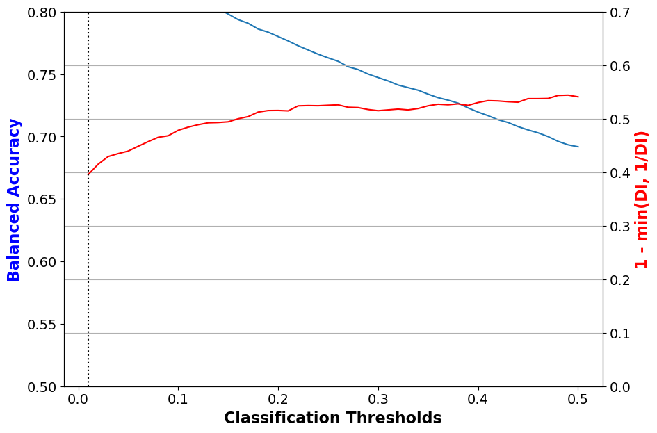

```python
disp_imp = np.array(val_metrics['disp_imp'])
disp_imp_err = 1 - np.minimum(disp_imp, 1/disp_imp)
plot(thresh_arr, 'Classification Thresholds',
     val_metrics['bal_acc'], 'Balanced Accuracy',
     disp_imp_err, '1 - min(DI, 1/DI)')
```

We can also write a function to describe the metrics:

```python
def describe_metrics(metrics, thresh_arr):
    best_ind = np.argmax(metrics['bal_acc'])
    print("Threshold corresponding to Best balanced accuracy: {:6.4f}".format(thresh_arr[best_ind]))
    print("Best balanced accuracy: {:6.4f}".format(metrics['bal_acc'][best_ind]))
    #disp_imp_at_best_ind = np.abs(1 - np.array(metrics['disp_imp']))[best_ind]
    disp_imp_at_best_ind = 1 - min(metrics['disp_imp'][best_ind], 1/metrics['disp_imp'][best_ind])
    print("Corresponding 1-min(DI, 1/DI) value: {:6.4f}".format(disp_imp_at_best_ind))
    print("Corresponding average odds difference value: {:6.4f}".format(metrics['avg_odds_diff'][best_ind]))
    print("Corresponding statistical parity difference value: {:6.4f}".format(metrics['stat_par_diff'][best_ind]))
    print("Corresponding equal opportunity difference value: {:6.4f}".format(metrics['eq_opp_diff'][best_ind]))
    print("Corresponding Theil index value: {:6.4f}".format(metrics['theil_ind'][best_ind]))
```

```python
describe_metrics(val_metrics, thresh_arr)
```

```
Threshold corresponding to Best balanced accuracy: 0.0100
Best balanced accuracy: 0.8975
Corresponding 1-min(DI, 1/DI) value: 0.3956
Corresponding average odds difference value: -0.0385
Corresponding statistical parity difference value: -0.0578
Corresponding equal opportunity difference value: -0.0251
Corresponding Theil index value: 0.0328
```

### 4.1 Bias mitigation using pre-processing technique – Rewighing (Transforming Data)

```python
RW = Reweighing(unprivileged_groups=unprivileged_groups,
                privileged_groups=privileged_groups)
dataset_transformed_train = RW.fit_transform(dataset_original_train)
```

Computing the disparate metric for the transformed data:

```python
metric_transformed_train = BinaryLabelDatasetMetric(
        dataset_transformed_train,
        unprivileged_groups=unprivileged_groups,
        privileged_groups=privileged_groups)

explainer_transformed_train = MetricTextExplainer(metric_transformed_train)
```

```
Disparate impact (probability of restraint given the patient is unprivileged (female) divided by the probability of restraint given the patient is privileged (male)): 1.0000000000000002
```

### 4.2 Learning a Logistic Regression (LR) classifier on data transformed by reweighing

```python
%%time

dataset = dataset_transformed_train
model = make_pipeline(StandardScaler(),
                      LogisticRegression(solver='liblinear', penalty = 'l1', random_state=1234))
fit_params = {'logisticregression__sample_weight': dataset.instance_weights}
lr_transformed = model.fit(dataset.features, dataset.labels.ravel(), **fit_params)
```

```
CPU times: user 22min 17s, sys: 2.57 s, total: 22min 20s
Wall time: 22min 24s
```

Running the same analysis as we did before to plot out the accuracy and fairness metrics over a range of classification thresholds (from **3.2**):

```python
thresh_arr = np.linspace(0.01, 0.5, 50)
val_metrics = test(dataset=dataset_original_validate,
                   model=lr_transformed,
                   thresh_arr=thresh_arr)
lr_transformed_best_ind = np.argmax(val_metrics['bal_acc'])
```

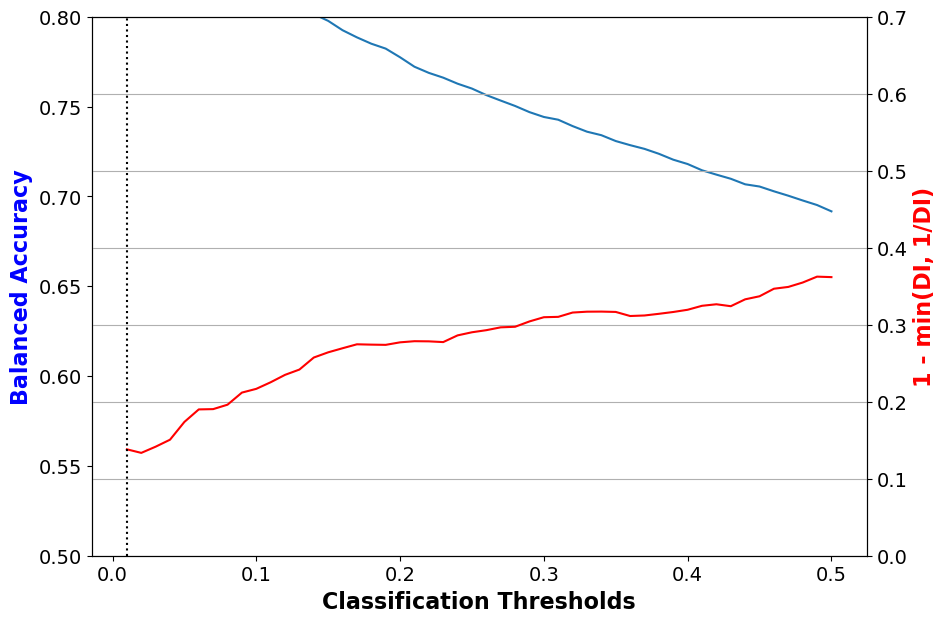

```python
disp_imp = np.array(val_metrics['disp_imp'])
disp_imp_err = 1 - np.minimum(disp_imp, 1/disp_imp)
plot(thresh_arr, 'Classification Thresholds',
     val_metrics['bal_acc'], 'Balanced Accuracy',
     disp_imp_err, '1 - min(DI, 1/DI)')
```

```python
describe_metrics(val_metrics, thresh_arr)
```

```
Threshold corresponding to Best balanced accuracy: 0.0100
Best balanced accuracy: 0.8947
Corresponding 1-min(DI, 1/DI) value: 0.1382
Corresponding average odds difference value: 0.0031
Corresponding statistical parity difference value: -0.0171
Corresponding equal opportunity difference value: 0.0175
Corresponding Theil index value: 0.0329
```

With the weights being changed, we were able to achieve a best accuracy of 0.8947 with a disparitiy index lower than 0.2, which in AIF360's definition means that the dataset is fair.

We can also display the [average odds difference](https://aif360.readthedocs.io/en/latest/modules/generated/aif360.sklearn.metrics.average_odds_difference.html), which returns the average of the difference in FPR and TPR for the unprivileged and privileged groups. A value of 0 implies both groups have equal benefit (which is what we want!).

$\text{Average odds difference} = \frac{(FPR_{unpriv}-FPR_{priv})+(TPR_{unpriv}-TPR_{priv})}{2}$

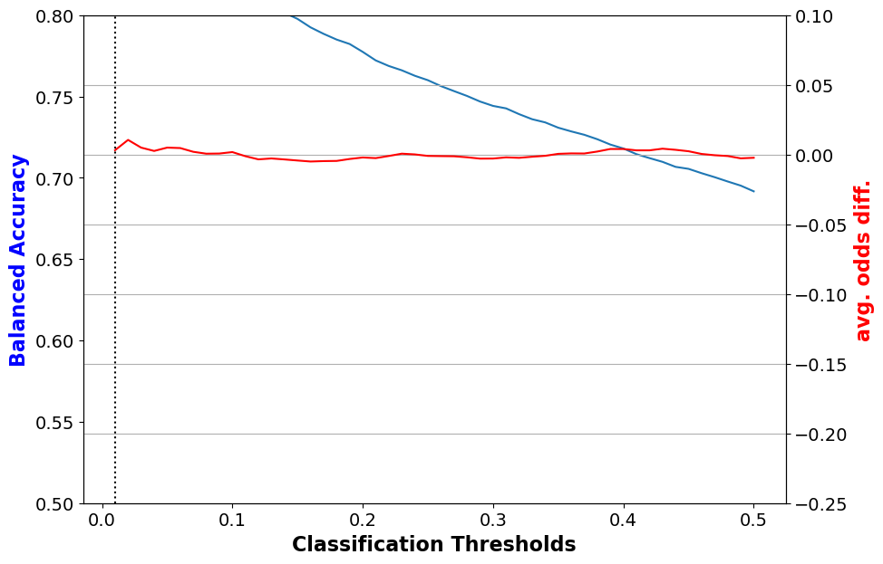

```python
plot(thresh_arr, 'Classification Thresholds',
     val_metrics['bal_acc'], 'Balanced Accuracy',
     val_metrics['avg_odds_diff'], 'avg. odds diff.')
```

### 4.3 Running LR model on test dataset after reweighing

```python
lr_transformed_metrics = test(dataset=dataset_original_test,
                         model=lr_transformed,
                         thresh_arr=[thresh_arr[lr_transformed_best_ind]])
```

```python
describe_metrics(lr_transformed_metrics, [thresh_arr[lr_transformed_best_ind]])
```

```
Threshold corresponding to Best balanced accuracy: 0.0100
Best balanced accuracy: 0.8956
Corresponding 1-min(DI, 1/DI) value: 0.1430
Corresponding average odds difference value: 0.0019
Corresponding statistical parity difference value: -0.0177
Corresponding equal opportunity difference value: 0.0154
Corresponding Theil index value: 0.0328
```

The fairness metrics for the logistic regression model learned after reweighing are well improved, and thus the model is much more fair relative to the logistic regression model learned from the original data.